# Atividade 6 - Modelos Lineares

### Alunos: Davi Augusto, Diogo Bolzan, João Arend, Luan Frederico e Thiago Schedler.

## Questão 1

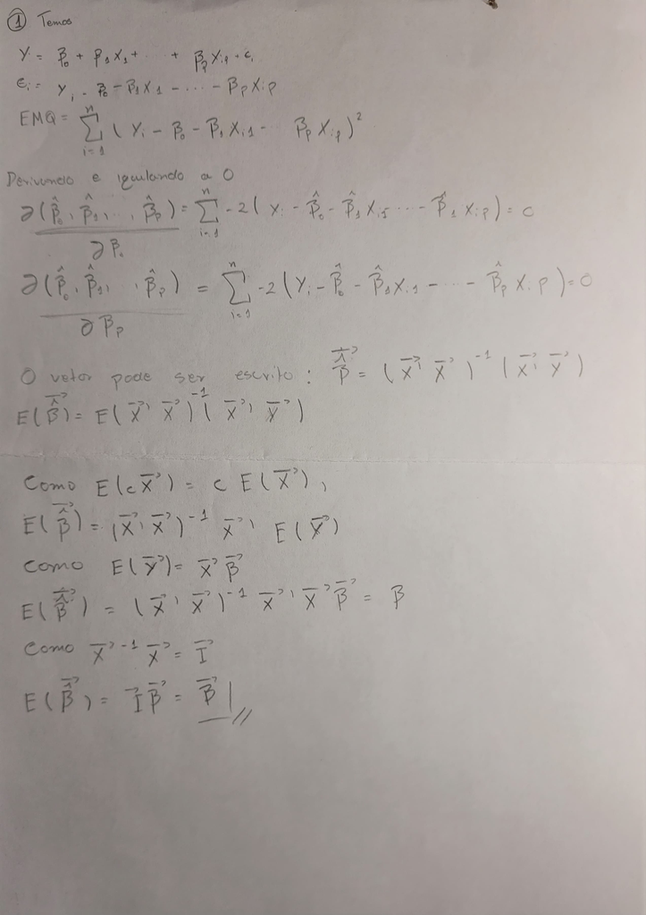

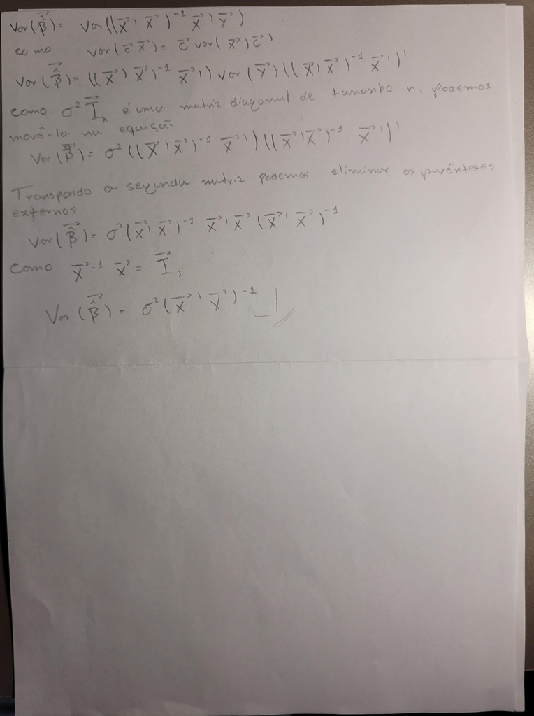

## Questão 2

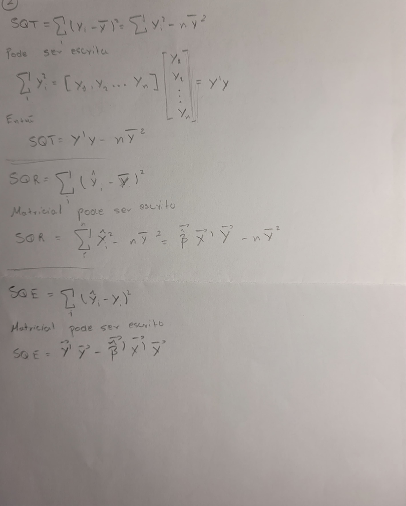

## Questão 3

### a) Estime e interprete os coeficientes do modelo de regressao.

```r
n <- 10
soma_y <- 20
soma_x1 <- 30
soma_x2 <- 40
soma_y2 <- 88.2
soma_x1_squared <- 92
soma_x2_squared <- 163
soma_yx1 <- 59
soma_yx2 <- 88
soma_x1x2 <- 119

# Matriz X'X
XTX <- matrix(c(
  n, soma_x1, soma_x2,
  soma_x1, soma_x1_squared, soma_x1x2,
  soma_x2, soma_x1x2, soma_x2_squared
), nrow = 3, byrow = TRUE)

# Vetor X'Y
XTY <- c(soma_y, soma_yx1, soma_yx2)

beta <- solve(XTX) %*% XTY
beta
```

```
##      [,1]
## [1,]  -13
## [2,]    1
## [3,]    3
```

```r
# Beta_{0} = -13
# Beta_{1} = 1
# Beta_{2} = 3
```

Interpretação:

**Intercepto ($B_{0})$**: Representa o valor esperado de $Y$ (-13) quando $X_{1}$ e $X_{2}$ é zero.

**Coeficiente de $X_{1}$ ($B_{1}$)**: Indica a variação em $Y$ para cada unidade de aumento em $X_{1}$, mantendo $X_{2}$ constante.

**Intercepto ($B_{0})$**: Representa o valor esperado de $Y$ (-13) quando $X_{1}$ e $X_{2}$ é zero.

**Coeficiente de $X_{2}$ ($B_{2}$)**: Indica a variação em $Y$ para cada unidade de aumento em $X_{2}$, mantendo $X_{1}$ constante.

### b) Calcule e interprete o coeficiente de determinação ajustado

$$R_{ajustado}^{2}=1-\frac{(1-R^{2})(n-1)}{n-k-1}$$
Onde:

- $R^{2}$: Coeficiente de determinação comum.
- $n$: Número de observações.
- $k$: Número de variáveis independentes.

```r
media_y <- soma_y / n
X <- matrix(c(rep(1, n), soma_x1 / n, soma_x2 / n), ncol = 3, byrow = TRUE)
Y_hat <- X %*% beta
# Calcular o R primeiro

## Soma de quadrados total
SQtotal <- soma_y2 - n * (media_y^2)

## Soma de quadrados dos resíduos
SQres <- soma_y2 - sum(Y_hat^2)

## Soma de quadrados da regressão
SQreg <- SQtotal - SQres

# Coeficiente de determinação (R^2)
R2 <- SQreg / SQtotal

# Coeficiente de determinação ajustado (R^2 ajustado)
R2_ajustado <- 1 - ((1 - R2) * (n - 1) / (n - 3))

R2_ajustado
```

```
## [1] 5.235922
```

Interpretação:

- $R^{2}:$ Mede a proporçaõ de variação total de $Y$ explicada pelas variáveis $X_{1}$ e $X_{2}$.
- $R_{ajustado}^{2}:$ Ajuda o $R^{2}$ para o número de variáveis independentes do modelo, penalizando a inclusão de variáveis irrelevantes.

### c) Calcule e interprete o intervalode 95% de confoança para o coeficiente angular de X1.

```r
# Soma de quadrados dos resíduos
SQres <- soma_y2 - t(beta) %*% XTY

sigma2 <- as.numeric(SQres / (n - 3))

# Erro padrão do coeficiente de X1
SE_beta1 <- sqrt(sigma2 * solve(XTX)[2, 2])

t_critico <- qt(0.975, df = n - 3)

# Intervalo de confiança para o coeficiente de X1
beta1 <- beta[2]
IC_beta1 <- c(
  beta1 - t_critico * SE_beta1,
  beta1 + t_critico * SE_beta1
)

IC_beta1
```

```
## [1] -2.475274  4.475274
```

O intervalo de confiança para o coeficiente $X_{1}$ é de [-2.47,4.47] e indica o intervalo dentro do qual o real coeficiente está presente com 95% de certeza. O intervalo contém o zero, e portanto o coeficiente não é estatisticamente significativo, inficando que $X_{1}$ não tem um efeito relevante sobre o $Y$.

### d) Teste a hipotese de que X2 exerce influencia linear sobre Y, a 5% de nível de significancia.

```r
sigma2 <- as.numeric(SQres / (n - 3))

# Erro padrão do coeficiente de X2
SE_beta2 <- sqrt(sigma2 * solve(XTX)[3, 3])

# Estatística t para X2
beta2 <- beta[3]
t_stat <- beta2 / SE_beta2

# Valor crítico de t para 95% de confiança (nível de significância 5%)
t_critico <- qt(0.975, df = n - 3)

p_valor <- 2 * (1 - pt(abs(t_stat), df = n - 3))

list(
  Estatistica_t = t_stat,
  Valor_critico = t_critico,
  p_valor = p_valor
)
```

```
## $Estatistica_t
## [1] 2.5
##
## $Valor_critico
## [1] 2.364624
##
## $p_valor
## [1] 0.04099222
```

Interpretação:

Como o valor de p é menor que 0.05, há evidencias para concluir que podemos rejeitar $H_{0}$ indicando que $X_{2}$ tem influência linear significativa.

### e) Teste a significancia global da regressao, a 5% de nível de significancia. Especifique as hipóteses e interprete.

```r
k <- 2
df_reg <- 2
df_res <- n - 3

# Estatística F
F_stat <- (SQreg / df_reg) / (SQres / df_res)

# Valor crítico de F
F_critico <- qf(0.95, df1 = df_reg, df2 = df_res)

p_valor <- 1 - pf(F_stat, df1 = df_reg, df2 = df_res)

list(
  Estatistica_F = F_stat,
  Valor_critico = F_critico,
  p_valor = p_valor
)
```

```
## $Estatistica_F
##       [,1]
## [1,] 28.75
##
## $Valor_critico
## [1] 4.737414
##
## $p_valor
##              [,1]
## [1,] 0.0004210989
```

Interpretação:

Como o valor de p é menor que 0.05, há evidencias para rejeitar $H_{0}$, indicando que o modelo é significativo.

## Questão 4

Dada a amostra abaixo, calcule. Y X1 X2 5 1 1 6 2 1 7 3 2 8 4 2 8 5 2

### a: Construa um intervalo de 90% de confiança para os parâmetros do modelo.

```r
modelo <- lm(Y ~ X1 + X2, data = dados)

cat("Intervalo de confiança de 90% para os parâmetros:\n")
```

```
## Intervalo de confiança de 90% para os parâmetros:
```

```r
confint(modelo, level = 0.90)
```

```
##                     5 %     95 %
## (Intercept)  2.17056040 5.696106
## X1          -0.07434178 1.274342
## X2          -1.27999039 2.613324
```

### b: Qual a equação de regressão estimada?

```r
coeficientes <- coef(modelo)

cat("Equação de regressão estimada:\n")
```

```
## Equação de regressão estimada:
```

```r
cat(sprintf("Y = %.2f + %.2f*X1 + %.2f*X2\n", coeficientes[1], coeficientes[2], coeficientes[3]))
```

```
## Y = 3.93 + 0.60*X1 + 0.67*X2
```

### c: Construa a tabela ANOVA, qual a sua conclusão?

```r
cat("Tabela anova:\n")
```

```
## Tabela anova:
```

```r
anova(modelo)
```

```
## Analysis of Variance Table
##
## Response: Y
##           Df Sum Sq Mean Sq F value Pr(>F)
## X1         1 6.4000  6.4000      48 0.0202 *
## X2         1 0.1333  0.1333       1 0.4226
## Residuals  2 0.2667  0.1333
## ---
## Signif. codes:  0 '***' 0.001 '**' 0.01 '*' 0.05 '.' 0.1 ' ' 1
```

### d: Calcule e interprete os coeficientes de determinação parciais de Y X1.X2 e Y X2.X21

```r
library(ppcor)
ry1_2 = pcor.test(y, x1, x2)
ry1_2
```

```
##    estimate   p.value statistic n gp  Method
## 1 0.8783101 0.1216899  2.598076 5  1 pearson
```

```r
(ry1_2$estimate)^2
```

```
## [1] 0.7714286
```

```r
ry2_1 = pcor.test(y, x2, x1)
ry2_1
```

```
##    estimate   p.value statistic n gp  Method
## 1 0.5773503 0.4226497         1 5  1 pearson
```

```r
(ry2_1$estimate)^2
```

```
## [1] 0.3333333
```

Portanto 77.1428571% da variabilidade de Y é explicada por X1 mantendo X2 constante e 33.3333333% da variabilidade de Y é explicada por X2 mantendo X1 constante. **obs:** Os valores estimados para coeficiente de correlação parcial não foram significativos.

## Questão 5

# Esboce graficamente o modelo estimado

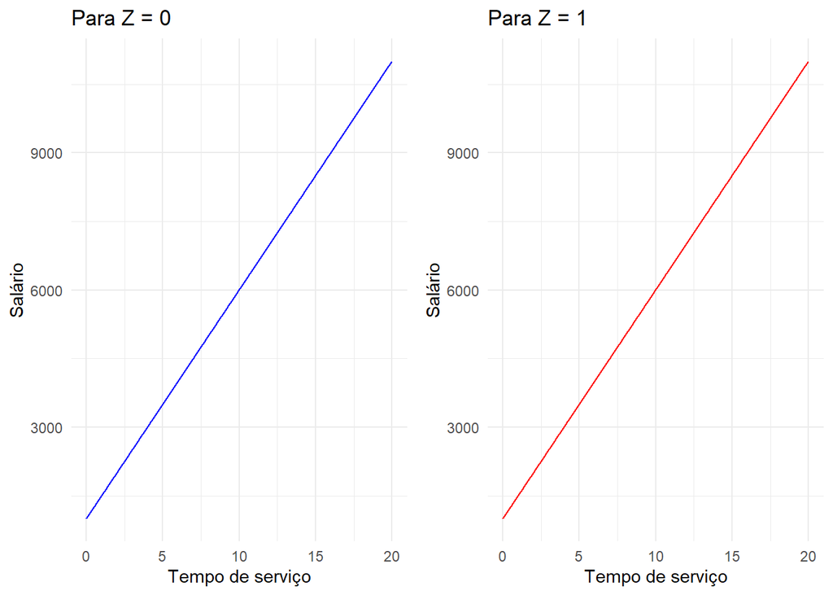

```r
library(gridExtra)
library(ggplot2)

# Configuração do modelo
beta0 <- 1000
beta1 <- 500
alpha1 <- 0.9

X <- seq(0, 20, by = 0.01)

# Calcular Y para Z = 0 e Z = 1
Y_Z0 <- beta0 + beta1 * X + (alpha1 * 0)
Y_Z1 <- beta0 + beta1 * X + (alpha1 * 1)


# Criar o gráfico
z0 = ggplot()+
  geom_line(aes(X,Y_Z0),color = "blue") +
  labs( x = "Tempo de serviço",
        y = "Salário",
        title =  "Para Z = 0") +
  theme_minimal()



z1 = ggplot()+
  geom_line(aes(X,Y_Z1),color = "red") +
  labs( x = "Tempo de serviço",
        y = "Salário",
        title =  "Para Z = 1") +
  theme_minimal()

grid.arrange(z0,z1,nrow=1,ncol= 2)
```

# Interprete o valor do coeficiente da variável Z

Espera-se que indivíduos com nível superior tenham, em média, um salário 0.9 unidades monetárias maior em comparação com aqueles sem nível superior. Embora positivo, o impacto da escolaridade no salário é relativamente pequeno em relação ao efeito do tempo de serviço, não sendo possível visualizar essa diferença nos gráficos acima.

# Teste, a 5% de significância, se existe influência do nível educacional no salário.

```r
beta_Z <- 0.9
se_beta_Z <- 0.1
n <- 20

t_stat <- beta_Z / se_beta_Z

df <- n - 2

t_crit <- qt(0.975, df)

p_value <- 2 * (1 - pt(abs(t_stat), df))

cat("Valor-p:", p_value, "\n")
```

```
## Valor-p: 4.404279e-08
```

Como o p-valor foi significativo, há evidências de que o nível educacional (variável Z) influencia o salário. No entanto, é importante observar que a magnitude dessa influência é pequena, com uma diferença salarial de apenas 0.9 unidades monetárias entre indivíduos com e sem nível superior. Isso sugere que, embora o nível educacional tenha um efeito estatisticamente significativo no salário, esse impacto é relativamente modesto em comparação com outras variáveis, como o tempo de serviço.

## Questão 6

Considere o seguinte modelo estimado para explicar salários via nível educacional e experiência profissional:

$$\widehat{\log(\text{salários})} = 7,42 + 0,29 \cdot \text{grad} + 0,04
\cdot \text{exper}$$

em que:

- $\text{grad} = 1$ se possui curso superior, e $0$ caso contrário;
- $\text{exper}$ são os anos de experiência profissional.

Além disso, os valores de ajuste do modelo são:

- $R^2 = 0,2731$,
- $R^2_{\text{ajustado}} = 0,152$,
- $n = 15$.

### a) Interprete os coecientes estimados neste modelo.

**Interpretação de $\beta_0$**: O intercepto ($\beta_0$) é o coeficiente $7,42$, que representa o valor esperado do logaritmo do salário ($\log(\text{salários})$) para indivíduos sem curso superior ($\text{grad} = 0$) e sem experiência profissional ($\text{exper} = 0$), que ocorre quando as variáveis **grad** e **exper** são iguais a zero. Como o modelo está em escala de logaritmos, $\beta_0$ não representa diretamente o salário, mas sim o logaritmo do salário. Para interpretar em termos de salário, é necessário calcular $e^{\beta_0}$, que forneceria o salário esperado.

**Interpretação de $\beta_1$**: O coeficiente $0,29$ significa que, mantendo-se constante a experiência profissional ($\text{exper}$), ter curso superior ($\text{grad} = 1$) está associado a um aumento médio de $29\%$ no salário em relação a não ter curso superior ($\text{grad} = 0$).

Essa interpretação decorre da propriedade exponencial dos logaritmos:

$$\Delta \log(\text{salários}) = 0,29 \implies \Delta \text{salários}
\approx e^{0,29} - 1 \approx 0,29 \, \text{(ou 29\%)}.$$

**Interpretação de $\beta_2$**: O coeficiente $0,04$ significa que, mantendo-se constante o nível educacional ($\text{grad}$), cada ano adicional de experiência profissional está associado a um aumento médio de $4\%$ no salário.

Assim como no caso anterior, isso pode ser interpretado usando a relação exponencial:

$$\Delta \log(\text{salários}) = 0,04 \implies \Delta \text{salários}
\approx e^{0,04} - 1 \approx 0,04 \, \text{(ou 4\%)}.$$

### b) Esboce o gráfico de log do salário em função da experiência profissional para pessoas com graduação e sem graduação.

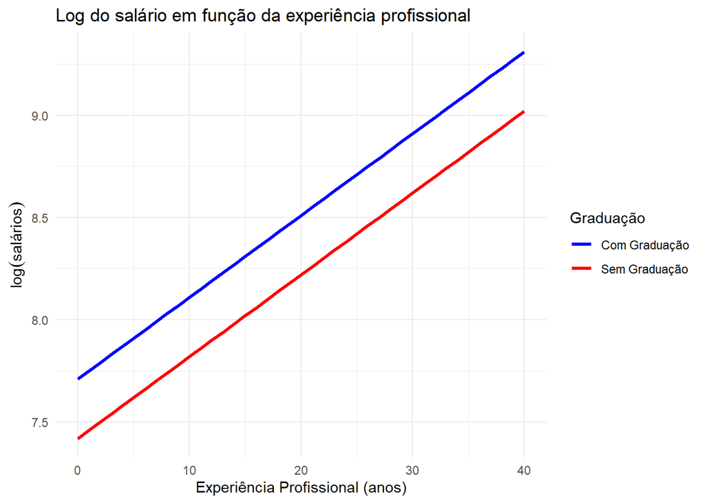

```r
# Criando os dados
exper = seq(0, 40, by = 1) # de 0 a 40 anos de experiência
log_salario_sem_grad = 7.42 + 0.04 * exper
log_salario_com_grad = 7.42 + 0.29 + 0.04 * exper

# Criando um data frame para o ggplot
dados = data.frame(
  Experiencia = rep(exper, 2),
  LogSalario = c(log_salario_sem_grad, log_salario_com_grad),
  Graduacao = rep(c("Sem Graduação", "Com Graduação"), each = length(exper))
)

# Gerando o gráfico
ggplot(dados, aes(x = Experiencia, y = LogSalario, color = Graduacao)) +
  geom_line(size = 1.2) +
  labs(
    title = "Log do salário em função da experiência profissional",
    x = "Experiência Profissional (anos)",
    y = expression(log(salários)),
    color = "Graduação"
  ) +
  theme_minimal() +
  scale_color_manual(values = c("blue", "red"))
```

### c) Proponha um modelo que considere diferentes inclinações na reta de regressão para graduados e não graduados.

$$\text{log(salário)} = \beta_0 + \beta_1 \cdot \text{exper} + \beta_2
\cdot \text{grad} + \beta_3 \cdot (\text{exper} \cdot \text{grad})$$

Para encontar o modelo acima, não há algum cálculo específico para encontrá-la, mas sim uma fundamentação baseada em teorias estatísticas.

Com base neste modelo, podemos encontrar os modelos para as pessoas com graduação e sem graduação, segue que:

Para não graduados ($\text{grad} = 0$): Substituímos $\text{grad} = 0$ na equação,o modelo fica assim:
$$\text{log(salário)} = \beta_0 + \beta_1 \cdot \text{exper}$$

Aqui, a inclinação em relação à experiência é apenas $\beta_1$.

Para graduados ($\text{grad} = 1$): Substituímos $\text{grad} = 1$ na equação:
$$\text{log(salário)} = \beta_0 + \beta_1 \cdot \text{exper} + \beta_2 +
\beta_3 \cdot \text{exper}$$

Aqui, a inclinação em relação à experiência é $\beta_1 + \beta_3$.

Em que O termo $\beta_3$ representa a diferença na inclinação da relação entre experiência e log do salário entre graduados e não graduados.

### d) Qual seria a hipótese nula para testar se há diferença nas inclinações entre graduados e não graduados no modelo do item anterior?

A hipótese nula para testar se há diferença nas inclinações entre graduados e não graduados no modelo do item anterior, que inclui o termo de interação, seria testar se o coeficiente de interação ($\beta_3$) é igual a zero. Assim, as hipóteses seriam:
$$H_0: \beta_3 = 0 \quad
vs \quad H_1: \beta_3 \neq 0$$

- Se $\beta_3 = 0$, isso indica que não há diferença na inclinação entre graduados e não graduados. Ou seja, a relação entre experiência e salário seria a mesma para os dois grupos.
- Se $\beta_3 \neq 0$, isso indica que há uma diferença significativa nas inclinações entre os dois grupos. Ou seja, a relação entre experiência e salário difere para graduados e não graduados.

Esta hipótese pode ser calculada através de um teste t para o coeficiente $\beta_3$ no modelo ajustado.